# Tarea3

Jason Solano and Percy Herrera

3/6/2020

## Tarea 3

En este documento se presenta un análisis parcial con la metodología CRISP-DM, en la cual se aplica un modelo descriptivo utilizando reglas de asociación. Por otra parte se interpretara dichas reglas para un análisis mas detallado.

## Objetivos

### Objetivo de mineria de datos

Encontar patrones y reglas de asociación que permitan determinar cuando una persona puede tener un ingreso mayor a 50 mil dorales al año.

### Objetivo del negocio

Encontar características que permitan identificar los usuarios o clientes que tenan ingresos de mas de 50 mil dolares al año.

## Librerías

### Librerías utilizadas

```r
library(arules)
```

```r
library(arulesViz)
library(tidyverse)
library(plyr)
library(ggplot2)
library(knitr)
library(lubridate)
library(RColorBrewer)
library(arules)
```

## Utilización de Datos

Cargamos el dataset que contiene información de residentes adultos de Estados Unidos

```r
datUSA<- read.csv('AdultosUSA.csv',sep=';',dec=',',stringsAsFactors = FALSE)
view(datUSA)
```

## Limpieza de datos

Removemos los datos nulos

```r
datosCompletosUSA<- na.omit(datUSA)
view(datosCompletosUSA)
```

Removemos datos con valores incongruentes

```r
datosCompletosUSA <- datUSA[!(datUSA$Edad=="" | datUSA$TipoTrabajo==""| datUSA$NivelEducativo==""|datUSA$NivelEducativo==""|datUSA$AnnosEducacion==""|datUSA$EstadoCivil==""|datUSA$Ocupacion==""|datUSA$Sexo==""|datUSA$HorasSemanales==""|datUSA$PaisOrigen==""|datUSA$Ingresos==""),]
view(datosCompletosUSA)
```

Observamos los datos

```r
summary(datosCompletosUSA)
```

```
##       Edad       TipoTrabajo        NivelEducativo     AnnosEducacion
##  Min.   :17.00   Length:25000       Length:25000       Min.   : 1.00
##  1st Qu.:28.00   Class :character   Class :character   1st Qu.: 9.00
##  Median :37.00   Mode  :character   Mode  :character   Median :10.00
##  Mean   :38.61                                         Mean   :10.08
##  3rd Qu.:48.00                                         3rd Qu.:12.00
##  Max.   :90.00                                         Max.   :16.00
##  EstadoCivil         Ocupacion             Sexo           HorasSemanales
##  Length:25000       Length:25000       Length:25000       Min.   : 1.00
##  Class :character   Class :character   Class :character   1st Qu.:40.00
##  Mode  :character   Mode  :character   Mode  :character   Median :40.00
##                                                           Mean   :40.41
##                                                           3rd Qu.:45.00
##                                                           Max.   :99.00
##   PaisOrigen          Ingresos
##  Length:25000       Length:25000
##  Class :character   Class :character
##  Mode  :character   Mode  :character
##
##
##
```

Las variables son no numéricas Se convierten a factor las variables TipoTrabajo, NivelEducativo, EstadoCivil, Ocupacion, Sexo, PaisOrigen y Ingresos

```r
datosCompletosUSA$TipoTrabajo<- as.factor(datosCompletosUSA$TipoTrabajo)

datosCompletosUSA$NivelEducativo<- as.factor(datosCompletosUSA$NivelEducativo)

datosCompletosUSA$EstadoCivil<- as.factor(datosCompletosUSA$EstadoCivil)

datosCompletosUSA$Ocupacion<- as.factor(datosCompletosUSA$Ocupacion)

datosCompletosUSA$Sexo<- as.factor(datosCompletosUSA$Sexo)

datosCompletosUSA$PaisOrigen<- as.factor(datosCompletosUSA$PaisOrigen)

datosCompletosUSA$Ingresos<- as.factor(datosCompletosUSA$Ingresos)
```

## Definición de Rangos

Para el caso de horas semanales, se definen los siguientes rangos, debido a que 20 horas son trabajos de medio tiempo y 40 horas son trabajos de tiempo completo

```r
datosCompletosUSA$HorasSemanales <- discretize(datosCompletosUSA$HorasSemanales, method="fixed",breaks = c(0, 20, 40,60,100))
```

Para el caso de edad, se empieza los rangos de 0 a 20 donde hay pocos ingresos, de 20 a 40 donde existe un gran crecimiento de ingresos y de 40 a 60 cerca de la pensión, y de 60 a 100 donde existen gran cantidad de salarios con pensión

```r
datosCompletosUSA$Edad <- discretize(datosCompletosUSA$Edad, method="fixed",breaks = c(0, 20, 40,60,100))
```

Para el caso de educación se divide de 0 a 5 años para el caso de personas con educación en primaria, secundaria de 5 a 10, para el caso universitario tipo bachillerato de 10 a 15, y maestrías o doctorados de 15 a 30

```r
datosCompletosUSA$AnnosEducacion <- discretize(datosCompletosUSA$AnnosEducacion, method="fixed",breaks = c(0, 5, 10,15,30))
```

Observamos los datos

```r
summary(datosCompletosUSA)
```

```
##        Edad                 TipoTrabajo         NivelEducativo AnnosEducacion
##  [0,20)  : 1257   Private         :17385   HS-grad     :8120   [0,5)  :  891
##  [20,40) :12793   Self-emp-not-inc: 1978   Some-college:5597   [5,10) :10467
##  [40,60) : 8930   Local-gov       : 1624   Bachelors   :4140   [10,15):12897
##  [60,100]: 2020   ?               : 1399   Masters     :1300   [15,30]:  745
##                   State-gov       :  993   Assoc-voc   :1059
##                   Self-emp-inc    :  857   11th        : 909
##                   (Other)         :  764   (Other)     :3875
##                 EstadoCivil              Ocupacion        Sexo
##  Divorced             : 3435   Prof-specialty :3180   Female: 8291
##  Married-AF-spouse    :   16   Craft-repair   :3122   Male  :16709
##  Married-civ-spouse   :11441   Exec-managerial:3084
##  Married-spouse-absent:  328   Adm-clerical   :2975
##  Never-married        : 8225   Sales          :2815
##  Separated            :  786   Other-service  :2555
##  Widowed              :  769   (Other)        :7269
##   HorasSemanales          PaisOrigen      Ingresos
##  [0,20)  : 1301   United-States:22421   <=50K.:19016
##  [20,40) : 4673   Mexico       :  488   >50K. : 5984
##  [40,60) :17034   ?            :  445
##  [60,100]: 1992   Philippines  :  151
##                   Germany      :  102
##                   Canada       :   99
##                   (Other)      : 1294
```

## Generación de reglas

Primero para generar reglas debemos convertir nuestros datos a tipo basket, para lo cual utilizamos el siguiente comando

```r
trns<- as(datosCompletosUSA,'transactions')

summary(trns)
```

```
## transactions as itemMatrix in sparse format with
##  25000 rows (elements/itemsets/transactions) and
##  105 columns (items) and a density of 0.0952381
##
## most frequent items:
## PaisOrigen=United-States          Ingresos=<=50K.      TipoTrabajo=Private
##                    22421                    19016                    17385
##   HorasSemanales=[40,60)                Sexo=Male                  (Other)
##                    17034                    16709                   157435
##
## element (itemset/transaction) length distribution:
## sizes
##    10
## 25000
##
##    Min. 1st Qu.  Median    Mean 3rd Qu.    Max.
##      10      10      10      10      10      10
##
## includes extended item information - examples:
##         labels variables  levels
## 1  Edad=[0,20)      Edad  [0,20)
## 2 Edad=[20,40)      Edad [20,40)
## 3 Edad=[40,60)      Edad [40,60)
##
## includes extended transaction information - examples:
##   transactionID
## 1             1
## 2             2
## 3             3
```

Se generan las reglas relacionadas con ingresos superiores a 50k:

```r
reglasIngresos50p<- apriori(trns,parameter =list(supp=0.001,conf=0.8),
                            appearance = list(default='lhs',rhs='Ingresos=>50K.')  )
```

```
## Apriori
##
## Parameter specification:
##  confidence minval smax arem  aval originalSupport maxtime support minlen
##         0.8    0.1    1 none FALSE            TRUE       5   0.001      1
##  maxlen target   ext
##      10  rules FALSE
##
## Algorithmic control:
##  filter tree heap memopt load sort verbose
##     0.1 TRUE TRUE  FALSE TRUE    2    TRUE
##
## Absolute minimum support count: 25
##
## set item appearances ...[1 item(s)] done [0.00s].
## set transactions ...[105 item(s), 25000 transaction(s)] done [0.02s].
## sorting and recoding items ... [85 item(s)] done [0.00s].
## creating transaction tree ... done [0.02s].
## checking subsets of size 1 2 3 4 5 6 7 8 9 10 done [0.23s].
## writing ... [1956 rule(s)] done [0.01s].
## creating S4 object  ... done [0.02s].
```

Observamos la cantidad de reglas

```r
length(reglasIngresos50p)
```

```
## [1] 1956
```

Filtramos las primeras reglas

```r
inspect(head(reglasIngresos50p))
```

```
##     lhs                                 rhs              support confidence     lift count
## [1] {TipoTrabajo=Self-emp-inc,
##      NivelEducativo=Doctorate}       => {Ingresos=>50K.} 0.00100  0.8333333 3.481506    25
## [2] {TipoTrabajo=State-gov,
##      NivelEducativo=Doctorate}       => {Ingresos=>50K.} 0.00248  0.8378378 3.500325    62
## [3] {NivelEducativo=Doctorate,
##      Ocupacion=Exec-managerial}      => {Ingresos=>50K.} 0.00160  0.8888889 3.713607    40
## [4] {Edad=[40,60),
##      NivelEducativo=Doctorate}       => {Ingresos=>50K.} 0.00596  0.8232044 3.439190   149
## [5] {NivelEducativo=Doctorate,
##      EstadoCivil=Married-civ-spouse} => {Ingresos=>50K.} 0.00708  0.8309859 3.471699   177
## [6] {TipoTrabajo=Self-emp-inc,
##      NivelEducativo=Prof-school}     => {Ingresos=>50K.} 0.00212  0.9464286 3.953996    53
```

Parte de la limpieza de reglas consta con eliminar la reglas que son subconjunto de otras

```r
subconjuntos<- which(colSums(is.subset(reglasIngresos50p,reglasIngresos50p))>1)

reglasFinal<- reglasIngresos50p[-subconjuntos]
```

Observamos la cantidad de reglas

```r
length(reglasFinal)
```

```
## [1] 101
```

Observamos las mejores 10 reglas

```r
inspect(sort(reglasFinal,by='support',decreasing = TRUE)[1:10])
```

```
##      lhs                                 rhs              support confidence     lift count
## [1]  {Edad=[40,60),
##       AnnosEducacion=[10,15),
##       EstadoCivil=Married-civ-spouse,
##       Ocupacion=Exec-managerial}      => {Ingresos=>50K.} 0.02384  0.8000000 3.342246   596
## [2]  {Edad=[40,60),
##       TipoTrabajo=Private,
##       EstadoCivil=Married-civ-spouse,
##       Ocupacion=Exec-managerial}      => {Ingresos=>50K.} 0.01844  0.8045375 3.361203   461
## [3]  {AnnosEducacion=[15,30],
##       EstadoCivil=Married-civ-spouse} => {Ingresos=>50K.} 0.01744  0.8304762 3.469570   436
## [4]  {AnnosEducacion=[15,30],
##       Ocupacion=Prof-specialty,
##       Sexo=Male}                      => {Ingresos=>50K.} 0.01568  0.8016360 3.349081   392
## [5]  {Edad=[40,60),
##       NivelEducativo=Masters,
##       EstadoCivil=Married-civ-spouse} => {Ingresos=>50K.} 0.01560  0.8315565 3.474083   390
## [6]  {NivelEducativo=Bachelors,
##       EstadoCivil=Married-civ-spouse,
##       Ocupacion=Exec-managerial,
##       Sexo=Male,
##       HorasSemanales=[40,60)}         => {Ingresos=>50K.} 0.01528  0.8093220 3.381192   382
## [7]  {Edad=[40,60),
##       TipoTrabajo=Private,
##       AnnosEducacion=[10,15),
##       Ocupacion=Exec-managerial,
##       Sexo=Male,
##       PaisOrigen=United-States}       => {Ingresos=>50K.} 0.01492  0.8021505 3.351231   373
## [8]  {NivelEducativo=Bachelors,
##       EstadoCivil=Married-civ-spouse,
##       Ocupacion=Exec-managerial,
##       HorasSemanales=[40,60),
##       PaisOrigen=United-States}       => {Ingresos=>50K.} 0.01468  0.8065934 3.369792   367
## [9]  {TipoTrabajo=Private,
##       NivelEducativo=Bachelors,
##       EstadoCivil=Married-civ-spouse,
##       Ocupacion=Exec-managerial}      => {Ingresos=>50K.} 0.01396  0.8060046 3.367332   349
## [10] {Edad=[40,60),
##       AnnosEducacion=[15,30]}         => {Ingresos=>50K.} 0.01316  0.8225000 3.436247   329
```

Observamos las tres mejores

```r
tresMejores <- head(sort(reglasFinal,by='support',decreasing = TRUE)[1:3])
inspect(tresMejores)
```

```
##     lhs                                 rhs              support confidence     lift count
## [1] {Edad=[40,60),
##      AnnosEducacion=[10,15),
##      EstadoCivil=Married-civ-spouse,
##      Ocupacion=Exec-managerial}      => {Ingresos=>50K.} 0.02384  0.8000000 3.342246   596
## [2] {Edad=[40,60),
##      TipoTrabajo=Private,
##      EstadoCivil=Married-civ-spouse,
##      Ocupacion=Exec-managerial}      => {Ingresos=>50K.} 0.01844  0.8045375 3.361203   461
## [3] {AnnosEducacion=[15,30],
##      EstadoCivil=Married-civ-spouse} => {Ingresos=>50K.} 0.01744  0.8304762 3.469570   436
```

## Se gráfica el resultado

```r
plot(tresMejores,method = 'graph',engine = 'htmlwidget')
```

[interactive chart not shown]

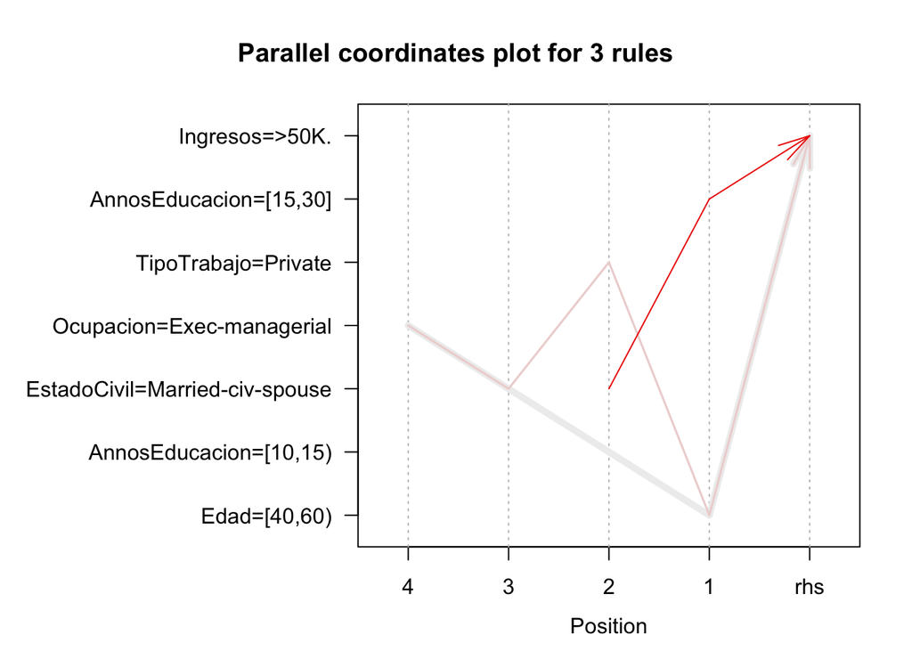

```r
plot(tresMejores,method ='paracoord')
```

## Conclusión

Como el anunciado de la tarea se indicaba el objetivo del negocio y de la mineria de datos es encontrar patrones y reglas que permitan identificar cuando una persona gana mas de 50 mil dolares para este caso se concluye lo siguiente

Patrones:

- Una persona con un grado de educación unversitario se puede deducir tipo maestria o doctorado, universitario tipo bachillerato
- Se su trabojo en el sector privado
- Edad Persona mayor de 40 años y menor de 60 años
- Ocupación gerencial
- Estado civil: casado de forma legal

Reglas:

- Edad=[40,60),AnnosEducacion=[10,15),stadoCivil=Married-civ-spouse,Ocupacion=Exec-managerial
- Edad=[40,60) TipoTrabajo=Private, EstadoCivil=Married-civ-spouse, Ocupacion=Exec-managerial
- AnnosEducacion=[15,30] EstadoCivil=Married-civ-spouse

Por lo tanto el negocio debe prestar atención a los clientes con dichas caractiristicas para ofrecer sus productos premium o de mayor costo que puedan ser comprados por personas que ganen mas de 50 mil dolares al año.